# Try3 Titanic Challenge

Michael Tzach

12/1/2017

# Third attempt at submission

The third attempt at submission to Kaggle used ensembles over previous model and recursive partitioning.

# Loading and Preprccessing

We run the same loading and preproccesing function for both the training and test data sets. What we try to do is to use the person’s title for the modeling. We can later see in the plots that some people with some titles had more or less chances of survival.

```r
mapNamesToTitles = function(y) {
  namesAsChars = lapply(y, as.character)
  firstPartOfNamesBeforeDots = lapply(namesAsChars, function(x) strsplit(x, '.', fixed = TRUE)[[1]][[1]])
  titlesPartOfNamesAsList = lapply(firstPartOfNamesBeforeDots, function(x) strsplit(x, ', ', fixed = TRUE)[[1]][[2]])
  titlesPartOfNamesAsList = lapply(titlesPartOfNamesAsList, function(x) if (x == "Dona") NA else x)
  return(factor(unlist(titlesPartOfNamesAsList)))
}

preprocessData = function(data, isTestData) {
  data$Pclass = factor(data$Pclass)
  data$Title = mapNamesToTitles(data$Name)
  if (isTestData) {
    data = subset(data, select=-c(Ticket, Cabin, Name))
  } else {
    data$Survived = factor(data$Survived)
    data = subset(data, select=-c(Ticket, Cabin, PassengerId, Name))
  }
}

dataFromFile = function(fileName, isTestData) {
  data = read.csv(fileName, na.string="")
  preprocessedData = preprocessData(data, isTestData)
  return(preprocessedData)
}

trainingData = dataFromFile("train.csv", FALSE)
testData = dataFromFile("test.csv", TRUE)
testDataWithPassengerIds = testData
testDataPassengerIds<- testData$PassengerId
testData = subset(testData, select=-c(PassengerId))
```

Install and load needed libraries

```r
if(!require(C50)){
  install.packages('C50')
}
library('C50')
if(!require(tidyr)) {
  install.packages("tidyr")
}
```

```r
library(tidyr)
if(!require(ggplot2)) {
  install.packages("ggplot2")
}
library(ggplot2)
if(!require(caret)) {
  install.packages("caret")
}
library(caret)
if(!require(e1071)) {
  install.packages("e1071")
}
library(e1071)
if(!require(rpart)) {
  install.packages('rpart')
}
if(!require(rpart)) {
  install.packages('rpart')
}
library(rpart)
if(!require(rattle)) {
  install.packages("rattle", dependencies=TRUE)
}
library(rattle)
if(!require(rpart.plot)) {
  install.packages('rpart.plot')
}
library(rpart.plot)
if(!require(caretEnsemble)) {
  install.packages('caretEnsemble')
}
library(caretEnsemble)
set.seed(123)
```

We want to understand the data better so we plot the different variables after cleaning the data a bit

```r
trainingData.Cols<- 1:dim(trainingData)[2]
trainingData.factors <- trainingData.Cols[sapply(trainingData,is.factor)]
trainingData.numerics <- trainingData.Cols[!sapply(trainingData,is.factor)]
trainingData.tidy_factors<-gather(trainingData[,trainingData.factors],"feature","value",-1)
trainingData.tidy_numerics<-gather(cbind(Survived=trainingData[,1],trainingData[,trainingData.numerics]),"feature","value",-1)
```

## Factors plot

First we can look at the factors. We can see that the Pclass has a lot of clear variance between different classes. This is expected since the upper classes had a lot more chances of getting to the deck in time to escape. The titles and sex are somewhat related. We can see that males had a lower chance of survival.

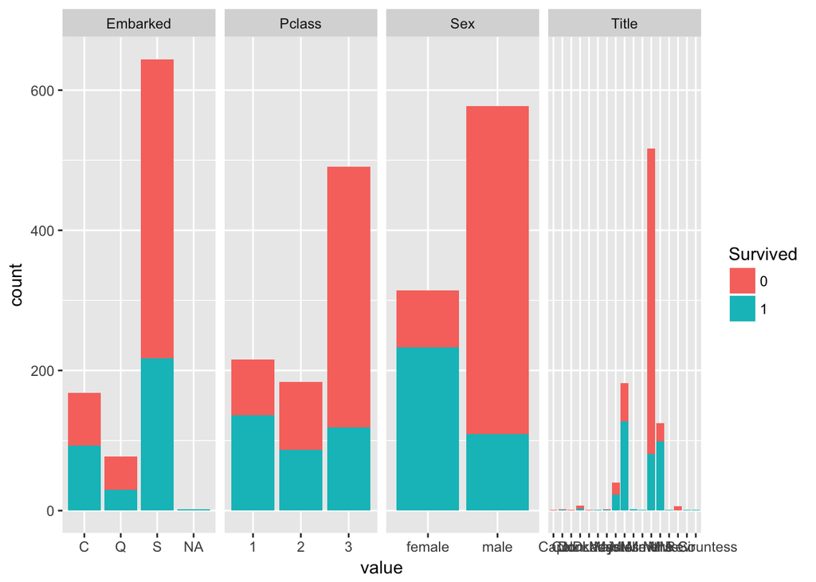

```r
qplot(x=value,data=trainingData.tidy_factors,fill=Survived) + facet_grid(~feature,scales="free")
```

When we look at non-factor data, we can see that children had higher chances of survival. There is a clear relation between the fare and the survival rate. This goes together with the pclass. People with no siblings had less chances of survival than those with at least one sibling. Same goes for passengers with or without parents or children.

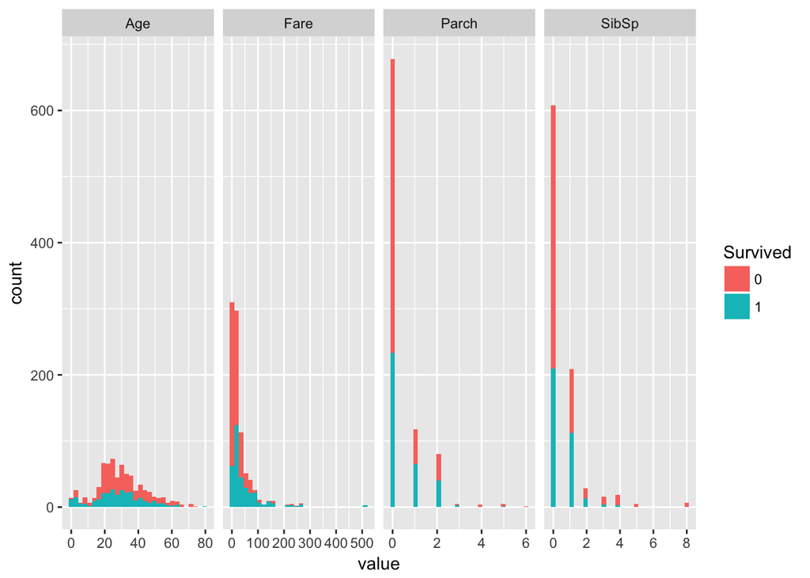

```r
qplot(x=value,data=trainingData.tidy_numerics,fill=Survived) + facet_grid(~feature,scales="free")
```

## Training and predictions

```r
control <- trainControl(method="cv", number=10)
fit.c50 <- train(Survived~., data=trainingData, method="C5.0", metric="Accuracy", trControl=control,na.action = na.pass)
fit.c50$xlevels[["Title"]] <- union(fit.c50$xlevels[["Title"]], levels(testData$Title))
```

Make the predictions and write them to a file

```r
fit.c50.testPredictions = predict(fit.c50,testData,na.action = na.pass)
fit.c50.res <- cbind(PassengerId=testDataPassengerIds,Survived=as.character(fit.c50.testPredictions))
```

### Recursive partitioning

We create results for the recursive partitioning.

```r
rpart.trainingDataModel <- rpart(Survived~., data = trainingData)
rpart.predictions <- predict(rpart.trainingDataModel, testData,type = "class")
rpart.res <- cbind(PassengerId=testDataPassengerIds,Survived=as.character(rpart.predictions))
```

This helps us with better understanding the data. We can see again that certain titles (especially male titles) had lower chances of survival and that the Pclass had a big influence.

[figure not shown]

```r
fancyRpartPlot(rpart.trainingDataModel)
```

# Ensamble

We need to clean the data for the ensamble method

```r
#Clean up the data for the ensamble
cleanUpBeforeEnsamble = function(data) {
  data = na.omit(data)
  feature.names=names(data)
  for (f in feature.names) {
    if (class(data[[f]])=="factor") {
      levels <- unique(c(data[[f]]))
      data[[f]] <- factor(data[[f]],labels=make.names(levels))
    }
  }
  return(data)
}
trainingData = cleanUpBeforeEnsamble(trainingData)
```

Since we ommited data from the test data, we need to later combine the ensamble predictions with a previous method.

```r
testData = cleanUpBeforeEnsamble(testDataWithPassengerIds)
passengerIdsPredictedWithensamble = testData$PassengerId
passengerIdsNotPredictedWithEnsamble = testDataPassengerIds[!(testDataPassengerIds %in% passengerIdsPredictedWithensamble)]
testData = subset(testData, select=-c(PassengerId))
```

Creating the ensamble model, We use two specs: one using c50 and the other using xgbTree. The parameters have been tuned to get best results

```r
ensambleModel.TrainControl = trainControl(method = "cv", number = 10, savePredictions='final', classProbs=TRUE)
ensambleModel.tuneList.C50 = caretModelSpec(method="C5.0",tuneGrid=data.frame(.trials=50, .model = 'tree', .winnow =FALSE))
ensambleModel.tuneList.XCGT = caretModelSpec(
    method = "xgbTree",
    tuneGrid = data.frame(
      .nrounds=30,
      .max_depth=3,
      .eta=0.4,
      .gamma=0.1,
      .colsample_bytree=0.7,
      .min_child_weight=0.01,
      .subsample=0.7
    )
  )
ensambleModel.tuneList = list(C50=ensambleModel.tuneList.C50, xgbTree=ensambleModel.tuneList.XCGT)
modelsForEnsamble<-caretList(Survived~., data=trainingData, trControl=ensambleModel.TrainControl, metric="Accuracy",tuneList=ensambleModel.tuneList)
```

Create the results. We usually get a mean result of 0.82 for both methods

```r
resultsFromEnsamble <- resamples(modelsForEnsamble)
summary(resultsFromEnsamble)
```

```
##
## Call:
## summary.resamples(object = resultsFromEnsamble)
##
## Models: C50, xgbTree
## Number of resamples: 10
##
## Accuracy
##              Min.   1st Qu.    Median      Mean   3rd Qu.      Max. NA's
## C50     0.7777778 0.8063380 0.8297787 0.8271367 0.8472222 0.8750000    0
## xgbTree 0.7777778 0.8035016 0.8112285 0.8188632 0.8398893 0.8611111    0
##
## Kappa
##              Min.   1st Qu.    Median      Mean   3rd Qu.      Max. NA's
## C50     0.5283019 0.5788042 0.6444003 0.6338256 0.6788007 0.7387097    0
## xgbTree 0.5274815 0.5831950 0.6074486 0.6156755 0.6616183 0.7080292    0
```

We predict the ensamle on the test data subset without the ommited values

```r
ensamble <- caretEnsemble(modelsForEnsamble)
ensamblePredictions = predict(ensamble, newdata=testData, type="raw")
```

We need to bind the data from the ensamble with another method. We get the ensamble results and combine it with a subset of the results from the recursive partitioning for the passenger ids that were ommited when cleaning the data for the ensamble.

```r
ensamblePredictions = unlist(lapply(as.character(ensamblePredictions), function(x) if (x == "X1") 0 else 1))
ensamblePredictions.res <- cbind(PassengerId=passengerIdsPredictedWithensamble,Survived=ensamblePredictions)
rpartResultsToCompleteResults = rpart.res[rpart.res[, "PassengerId"] %in% passengerIdsNotPredictedWithEnsamble,]
finalResults = rbind(ensamblePredictions.res, rpartResultsToCompleteResults)
```

```r
write.csv(finalResults,file="try3.csv",row.names = F)
```

# Results

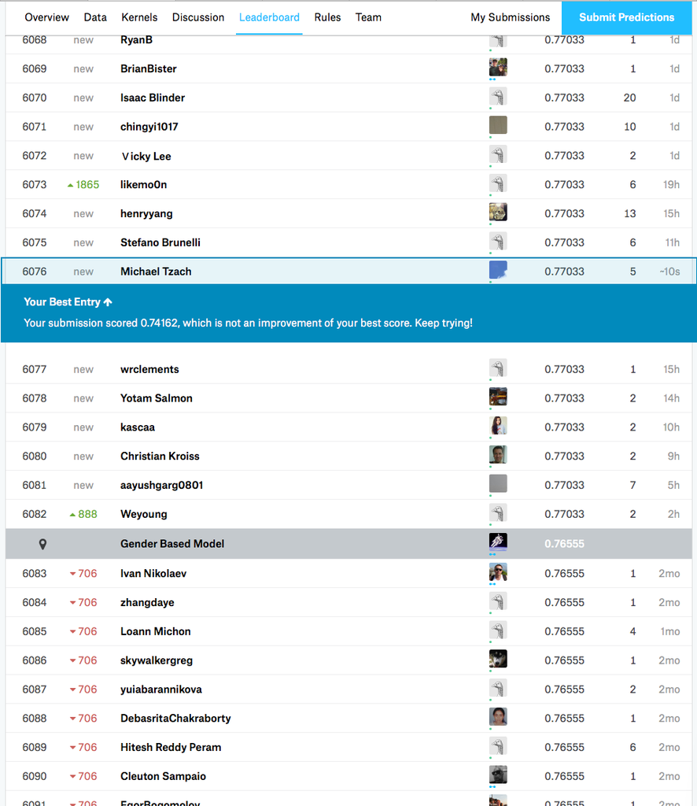

Kaggle Screenshot